# USCOTS 2023 Quarto Workshop - Welcome to Posit Cloud!

Author

Your Name Here!

Published

April 7, 2023

# Quarto

This is a Quarto document!

Quarto is a software that allows you to interweave text and R code to create HTML, PDF, and Microsoft Word documents

There are two ways to view a Quarto document, (1) as the “Source” file, or (2) as the “Visual” file. We will **only** use the Visual option in this class, as it allows you to interact with Quarto similar to how you interact with Word.

## Formatting your Document

Similar to a Word Doc, there are a variety of ways you can spice up a Quarto document! Let’s explore a few.

**Question 1:** Using the formatting options, make a numbered list of your top three favorite animals.

**Question 2:** Using the formatting options, insert an image of your favorite animal.

**Question 3:** Now, change the “Formatting your Document” section name to the name of your favorite animal. Make sure your header is a level 1 – use the Header 1 formatting option!

## R Code

You can differentiate the R code within a Quarto file from the body of the document, based on the gray boxes that start with an `{r}.`

1. The `#| include: false` option at the beginning of the code chunk. We use these options to control how the code output looks in our final rendered document.
2. The `library(tidyverse)` code loads in an R package called the “tidyverse”. This is code you will have in **every** lab assignment for this class!
3. Code comments which are denoted by a `##` symbol. Code comments are a way for you (and me) to write what the code is doing, without R thinking what we are writing is code it should execute.

## Rendering

**Question 4:** Do you see the above code chunk when you knit the document? Why do you think this is the case?

## Including Code Output

You can include code output in your knitted document:

```r
glimpse(mpg)
```

```
Rows: 234
Columns: 11
$ manufacturer <chr> "audi", "audi", "audi", "audi", "audi", "audi", "audi", "…
$ model        <chr> "a4", "a4", "a4", "a4", "a4", "a4", "a4", "a4 quattro", "…
$ displ        <dbl> 1.8, 1.8, 2.0, 2.0, 2.8, 2.8, 3.1, 1.8, 1.8, 2.0, 2.0, 2.…
$ year         <int> 1999, 1999, 2008, 2008, 1999, 1999, 2008, 1999, 1999, 200…
$ cyl          <int> 4, 4, 4, 4, 6, 6, 6, 4, 4, 4, 4, 6, 6, 6, 6, 6, 6, 8, 8, …
$ trans        <chr> "auto(l5)", "manual(m5)", "manual(m6)", "auto(av)", "auto…
$ drv          <chr> "f", "f", "f", "f", "f", "f", "f", "4", "4", "4", "4", "4…
$ cty          <int> 18, 21, 20, 21, 16, 18, 18, 18, 16, 20, 19, 15, 17, 17, 1…
$ hwy          <int> 29, 29, 31, 30, 26, 26, 27, 26, 25, 28, 27, 25, 25, 25, 2…
$ fl           <chr> "p", "p", "p", "p", "p", "p", "p", "p", "p", "p", "p", "p…
$ class        <chr> "compact", "compact", "compact", "compact", "compact", "c…
```

**Question 5:** What do you think the above code does? What type of output does it give you?  
*Hint: You have saw this type of output earlier today!*

## Including Plots

You can also embed plots in the rendered document.

Here is an example of a plot.

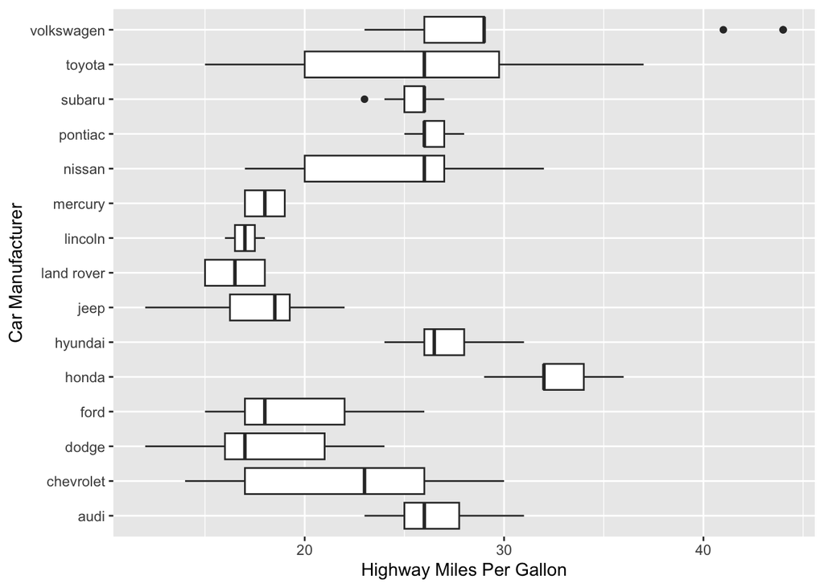